# RNASeq

Author

Truc Bui

Published

November 22, 2025

# Load packages and Data

```r
library(dplyr)
library(biomaRt)
library(ggplot2)
library(sva)
library(pbapply)
library(ggrepel)
library(tximport)
library(DESeq2)
library(gplots)
library(data.table)
library(UpSetR)
library(pheatmap)
```

```r
samples <- list.files("rsem_star_threshold_modified")
expr <- sapply(samples, function(sample){
  file <- paste0("rsem_star_threshold_modified//",sample,"/", sample, ".genes.results")
  quant <- read.csv(file, sep="\t", header=T)
  tpm <- setNames(quant$TPM, quant$gene_id)
  return(tpm)
})
```

```r
meta <- read.csv("SraRunTable.csv", header=T)
meta[, "Organ"] <- as.factor(meta[, "Organ"])
meta[, "condition"] <- as.factor(meta[, "condition"])
meta$group <- paste(meta$Organ, meta$condition, sep = "_")
meta$group <- as.factor(meta$group)
expr <- expr[,meta$Run]
```

```r
ensembl <- useEnsembl(biomart = "ensembl",
                      dataset = "mmusculus_gene_ensembl")
meta_genes <- getBM(attributes = c("mgi_symbol",
                                   "uniprot_gn_id",
                                   "ensembl_gene_id",
                                   "ensembl_gene_id_version",
                                   "hgnc_symbol",
                                   "description",
                                   "chromosome_name",
                                   "start_position",
                                   "end_position",
                                   "strand"),
                    filters = "uniprot_gn_id",
                    values = rownames(expr),
                    mart = ensembl) %>%
  right_join(data.frame(uniprot_gn_id = rownames(expr)),
             by = "uniprot_gn_id") %>%
  distinct(uniprot_gn_id, .keep_all = TRUE)

expr <- expr[meta_genes$uniprot_gn_id,]
```

# Comparison across samples

```r
dim(expr)
```

```
[1] 136424     12
```

## Check average expression levels

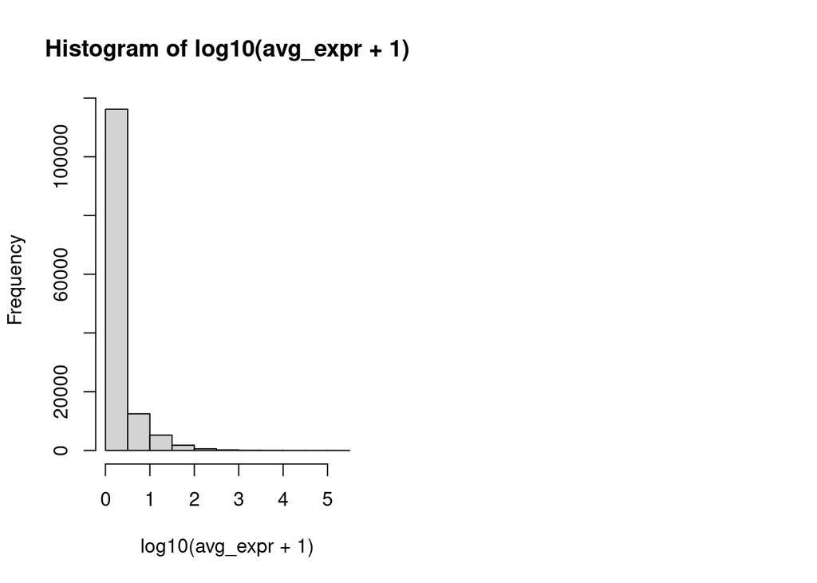

```r
avg_expr <- rowMeans(expr)

layout(matrix(1:2, nrow=1))
hist(log10(avg_expr + 1))
```

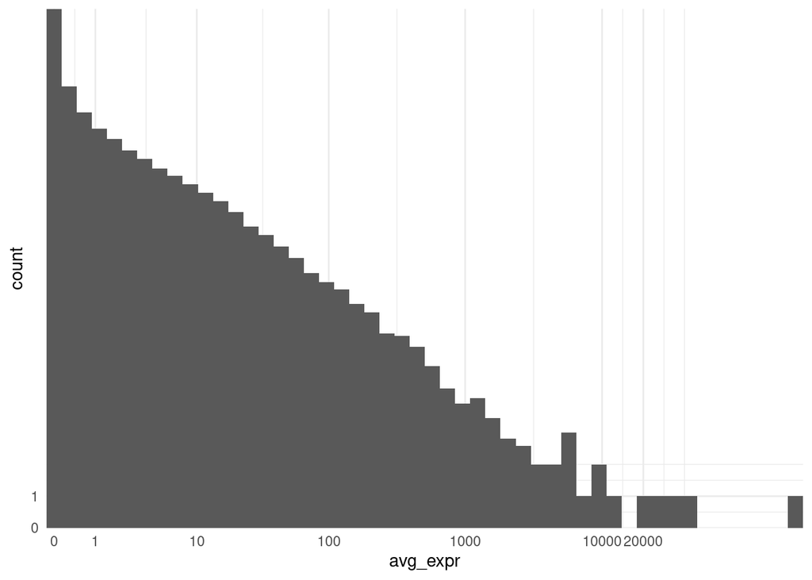

```r
ggplot(data.frame(avg_expr), aes(x=avg_expr)) +
  geom_histogram(bins = 50) +
  scale_x_continuous(breaks = c(0,1,10,100,1000,10000,20000), trans="log1p", expand=c(0,0)) +
  scale_y_continuous(breaks = c(0,1), expand=c(0,0), trans="log1p") +
  theme_minimal()
```

The y-axis is dominated by the very first bin which includes all the unexpressed genes. Therefore, we need to do a log-transformation on the y-axis.

## Check in how many samples each gene is detected

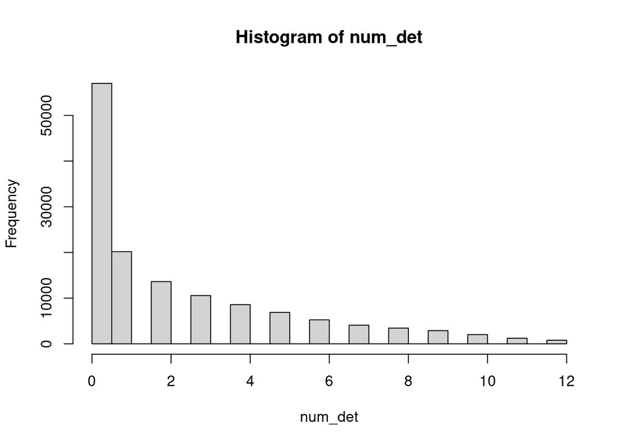

```r
num_det <- rowSums(expr > 0)
hist(num_det)
```

Here we are going to use the threshold of 1) being detected in at least half of the samples, or 2) average TPM>=1, to define whether a gene is expressed or not.

```r
expressed <- rowMeans(expr > 0) >= 0.5 | rowMeans(expr) >= 1
#expr <- expr[which(expressed),]
#meta_genes <- meta_genes[which(expressed),]
meta_genes$expressed <- expressed
# Number of expressing genes
sum(meta_genes$expressed==T)
```

```
[1] 32624
```

## Calculate correlation

```r
corr_pearson <- cor(log1p(expr[meta_genes$expressed,]))
corr_spearman <- cor(expr[meta_genes$expressed,], method = "spearman")
```

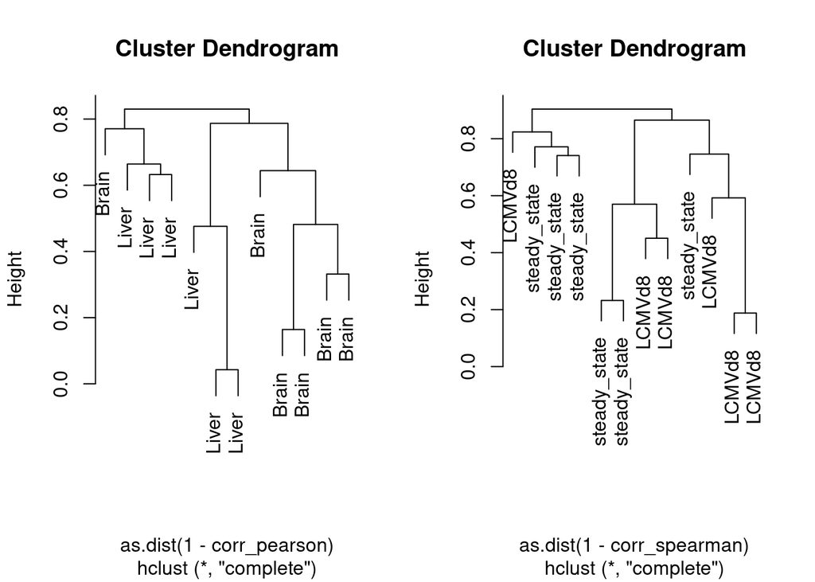

```r
hcl_pearson <- hclust(as.dist(1 - corr_pearson))
hcl_spearman <- hclust(as.dist(1 - corr_spearman))

layout(matrix(1:2,nrow=1))
plot(hcl_pearson, labels = meta$Organ)
plot(hcl_spearman, labels = meta$condition)
```

```r
layout(matrix(1:1,nrow=1))
```

## PCA

```r
pca <- prcomp(log1p(t(expr[meta_genes$expressed,])), center = TRUE, scale. = TRUE)
```

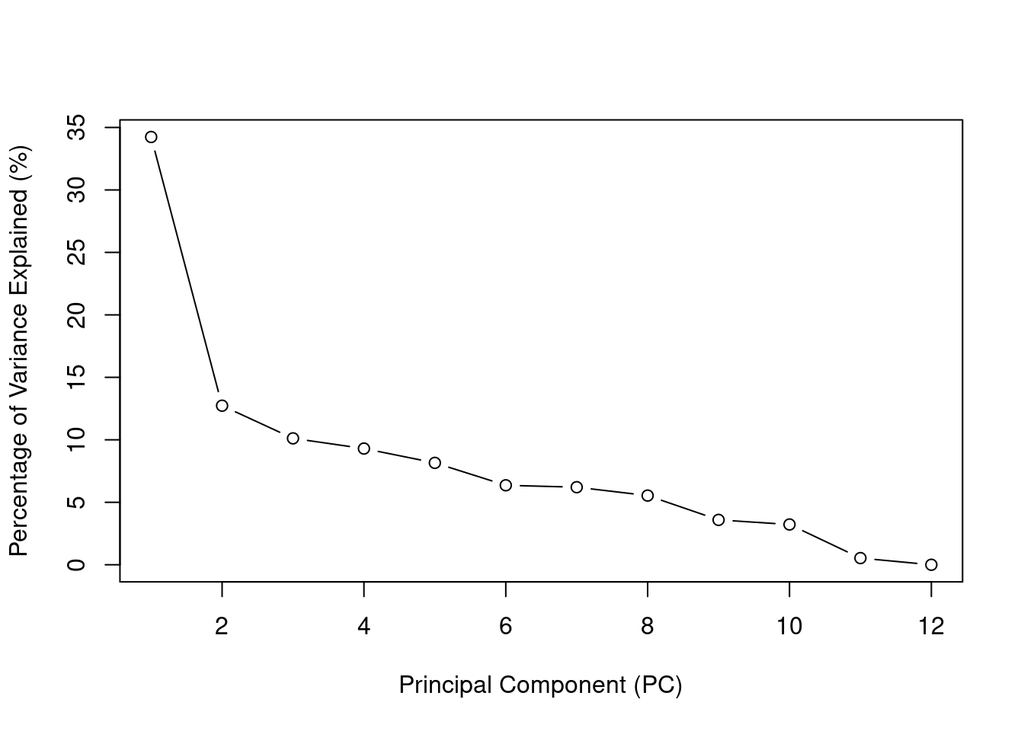

```r
eigs <- pca$sdev^2
percent_variance <- (eigs / sum(eigs)) * 100
plot(percent_variance, type = "b",
     xlab = "Principal Component (PC)",
     ylab = "Percentage of Variance Explained (%)")
```

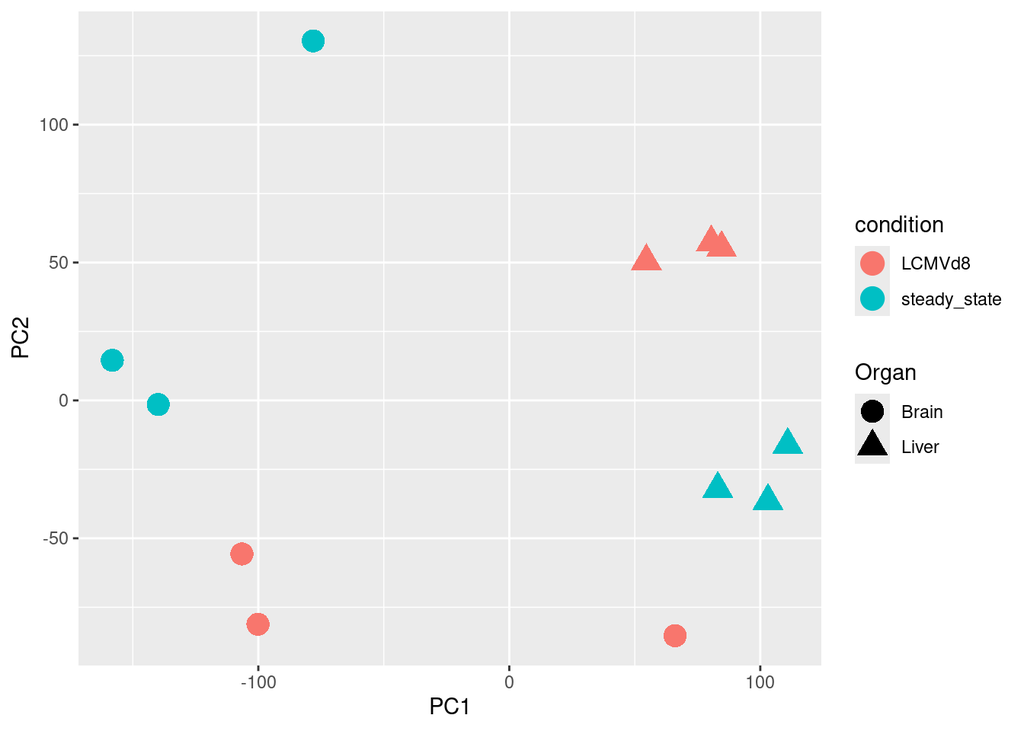

```r
ggplot(data.frame(pca$x, meta)) +
  geom_point(aes(x = PC1, y = PC2, color = condition, shape = Organ), size = 5)
```

### **Highly variable genes identification**

```r
estimate_variability <- function(expr){
  means <- apply(expr, 1, mean)
  vars <- apply(expr, 1, var)
  cv2 <- vars / means^2

  minMeanForFit <- unname(median(means[which(cv2 > 0.3)]))
  useForFit <- means >= minMeanForFit
  fit <- glm.fit(x = cbind(a0 = 1, a1tilde = 1/means[useForFit]),
                 y = cv2[useForFit],
                 family = Gamma(link = "identity"))
  a0 <- unname(fit$coefficients["a0"])
  a1 <- unname(fit$coefficients["a1tilde"])

  xg <- exp(seq(min(log(means[means>0])), max(log(means)), length.out=1000))
  vfit <- a1/xg + a0
  df <- ncol(expr) - 1
  afit <- a1/means+a0
  varFitRatio <- vars/(afit*means^2)
  pval <- pchisq(varFitRatio*df,df=df,lower.tail=F)

  res <- data.frame(mean = means,
                    var = vars,
                    cv2 = cv2,
                    useForFit = useForFit,
                    pval = pval,
                    padj = p.adjust(pval, method="BH"),
                    row.names = rownames(expr))
  return(res)
}
```

### Test for significance of overdispersion:

```r
var_genes <- estimate_variability(expr[meta_genes$expressed,])
meta_genes$highvar <- meta_genes$uniprot_gn_id %in% rownames(var_genes)[which(var_genes$padj < 0.01)]
```

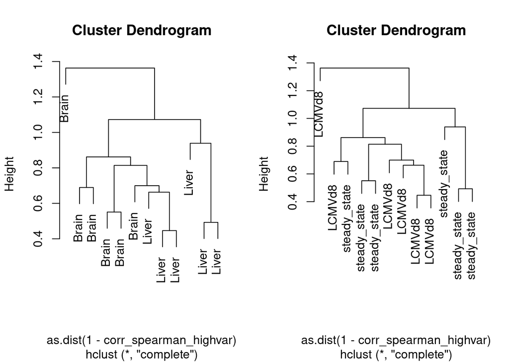

```r
corr_spearman_highvar <- cor(expr[meta_genes$highvar,], method = "spearman")
hcl_spearman_highvar <- hclust(as.dist(1 - corr_spearman_highvar))
layout(matrix(1:2,nrow=1))
plot(hcl_spearman_highvar, labels = meta$Organ)
plot(hcl_spearman_highvar, labels = meta$condition)
```

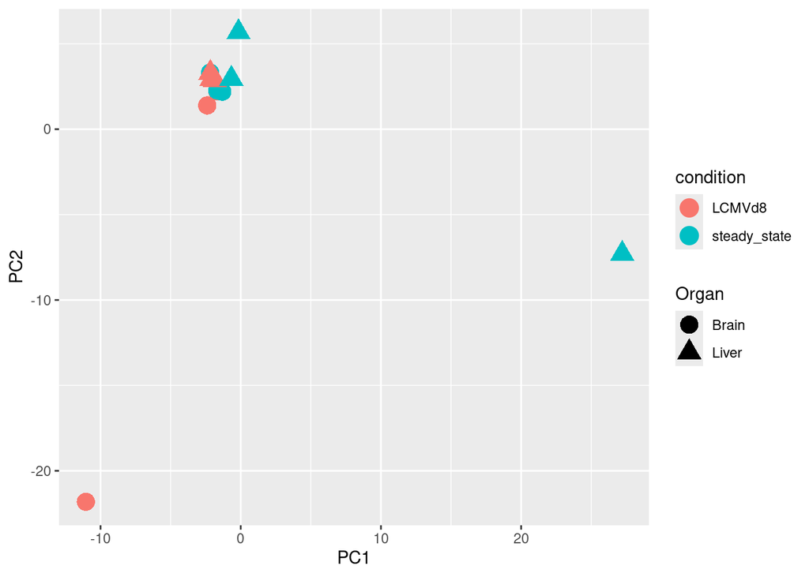

```r
pca_highvar <- prcomp(log1p(t(expr[meta_genes$highvar,])), center = TRUE, scale. = TRUE)
ggplot(data.frame(pca_highvar$x, meta)) +
  geom_point(aes(x = PC1, y = PC2, color = condition, shape = Organ), size = 5)
```

The PCA plot is not better in this case.

# **Differential expression analysis**

## First approach (ANOVA)

```r
DE_test <- function(expr,
                    cond,
                    ctrl = NULL,
                    covar = NULL,
                    padj_method = p.adjust.methods){
  pval_fc <- data.frame(t(pbapply(expr, 1, function(e){
    dat <- data.frame(y = log1p(e),
                      cond = cond)
    if (! is.null(covar))
      dat <- data.frame(dat, covar)

    m1 <- lm(y ~ ., data = dat)
    m0 <- lm(y ~ . - cond, data = dat)
    test <- anova(m1, m0)
    pval <- test$Pr[2]

    avgs <- tapply(log1p(e), cond, mean)
    if (! is.null(ctrl) && sum(cond %in% ctrl) > 0){
      fc <- exp(max(avgs[names(avgs) != ctrl]) - avgs[ctrl])
    } else{
      fc <- exp(max(avgs) - min(avgs))
    }

    return(c(pval = unname(pval), fc = unname(fc)))
  })), row.names = rownames(expr))
  padj <- p.adjust(pval_fc$pval, method = padj_method)
  return(data.frame(pval_fc, "padj" = padj)[,c("pval","padj","fc")])
}

res_DE <- DE_test(expr = expr[meta_genes$expressed,], # subset to only expressing genes
                  cond = meta$condition,
                  covar = meta %>% dplyr::select(Organ)) %>%
  tibble::rownames_to_column("gene")
```

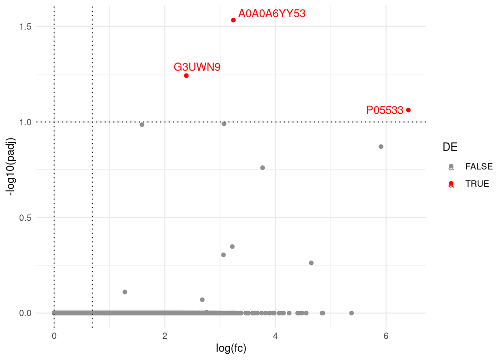

```r
res_DE <- res_DE %>%
  mutate(DE = padj < 0.1 & fc > 2) %>%
  mutate(DEG = ifelse(DE, gene, NA))

ggplot(res_DE, aes(x = log(fc), y = -log10(padj), col=DE, label=DEG)) +
  geom_point() +
  geom_text_repel() +
  geom_vline(xintercept=c(log(2), 0), col="#303030", linetype="dotted") +
  geom_hline(yintercept=-log10(0.1), col="#303030", linetype="dotted") +
  scale_color_manual(values=c("#909090", "red")) +
  theme_minimal()
```

The DEG are: A0A0A6YY53, P05533, G3UWN9.

## **DESeq2 (Main work!)**

```r
tx2gene <- getBM(attributes = c("uniprot_gn_id","ensembl_transcript_id_version",
                                "ensembl_gene_id", "mgi_symbol"),
                 filters = "uniprot_gn_id",
                 values = rownames(expr),
                 mart = ensembl) %>%
  dplyr::select(ensembl_transcript_id_version, ensembl_gene_id, uniprot_gn_id, mgi_symbol)

files <- file.path("rsem_star_threshold_modified", samples, paste0(samples,".isoforms.results"))
txi <- tximport(files, type = "rsem", tx2gene = tx2gene)
```

```
reading in files with read_tsv
```

```
1 2 3 4 5 6 7 8 9 10 11 12
removing duplicated transcript rows from tx2gene
transcripts missing from tx2gene: 48557
summarizing abundance
summarizing counts
summarizing length
```

```r
dds <- DESeqDataSetFromTximport(txi, colData = meta, design = ~ Organ + condition)
```

```
using counts and average transcript lengths from tximport
```

Apply expression threshold filtering to the object by subsetting only those we consider as expressed above

```r
abundances <- txi$abundance
colnames(abundances) <- samples
expressed_dds <- rowMeans(abundances > 0) >= 0.5 | rowMeans(abundances) >= 1
dds_filtered <- dds[which(expressed_dds), ]
```

Run DESeq2 using different approaches:

```r
# organ effect
design(dds_filtered) <- ~ Organ + condition
dds_org <- DESeq(dds_filtered, test = "LRT", reduced = ~ condition)
```

```
using 'avgTxLength' from assays(dds), correcting for library size
```

```r
res_org <- results(dds_org)
res_org_df <- as.data.frame(res_org) %>% tibble::rownames_to_column("gene_ensembl_ID")

# condition effect
design(dds_filtered) <- ~ Organ + condition
dds_cond <- DESeq(dds_filtered, test = "LRT", reduced = ~ Organ)
```

```
using 'avgTxLength' from assays(dds), correcting for library size
```

```r
res_cond <- results(dds_cond)
res_cond_df <- as.data.frame(res_cond) %>% tibble::rownames_to_column("gene_ensembl_ID")

# interaction effect
design(dds_filtered) <- ~ Organ + condition + Organ:condition
dds_int <- DESeq(dds_filtered, test = "LRT", reduced = ~ Organ + condition)
```

```
using 'avgTxLength' from assays(dds), correcting for library size
```

```r
res_int <- results(dds_int)
res_int_df <- as.data.frame(res_int) %>% tibble::rownames_to_column("gene_ensembl_ID")
```

```r
plot_volcano <- function(res_DESeq2_df) {

  res_DESeq2_df$gene <- meta_genes$mgi_symbol[match(res_DESeq2_df$gene_ensembl_ID,
                                                    meta_genes$ensembl_gene_id)]

  padj_threshold <- 0.05
  lfc_threshold <- 1.5

  top_10_up <- res_DESeq2_df %>%
    filter(padj < padj_threshold & log2FoldChange > lfc_threshold) %>%
    slice_min(order_by = padj, n = 5) %>%
    pull(gene)

  top_10_down <- res_DESeq2_df %>%
    filter(padj < padj_threshold & log2FoldChange < -lfc_threshold) %>%
    slice_min(order_by = padj, n = 5) %>%
    pull(gene)

  genes_to_label <- c(top_10_up, top_10_down)

  plot_df <- res_DESeq2_df %>%
    mutate(
      DE_group = case_when(
        padj < padj_threshold & log2FoldChange > lfc_threshold  ~ "Up-regulated",
        padj < padj_threshold & log2FoldChange < -lfc_threshold ~ "Down-regulated",
        TRUE                                                  ~ "Not Significant"
      ),
      # Create the new label column
      DEG_label = ifelse(gene %in% genes_to_label, gene, NA_character_)
    )

  ggplot(plot_df, aes(x = log2FoldChange, y = -log10(padj), col = DE_group, label = DEG_label)) +
    geom_point(aes(color = DE_group), size = 1.5) +

    geom_text_repel(
        max.overlaps = Inf, # Allow labels to overlap, but ggrepel will try its best
        box.padding = 0.5,
        point.padding = 0.2,
        segment.color = 'grey50'
    ) +

    geom_vline(xintercept = c(-lfc_threshold, lfc_threshold), col = "gray", linetype = "dotted") +
    geom_hline(yintercept = -log10(padj_threshold), col = "gray", linetype = "dotted") +

    scale_color_manual(values = c(
      "Down-regulated" = "blue",
      "Not Significant" = "grey80",
      "Up-regulated" = "red"
    )) +

    theme_minimal() +
    labs(
      title = "Volcano Plot",
      x = "log2 Fold Change",
      y = "-log10 (Adjusted P-value)"
    ) +
    theme(legend.title = element_blank())
}
```

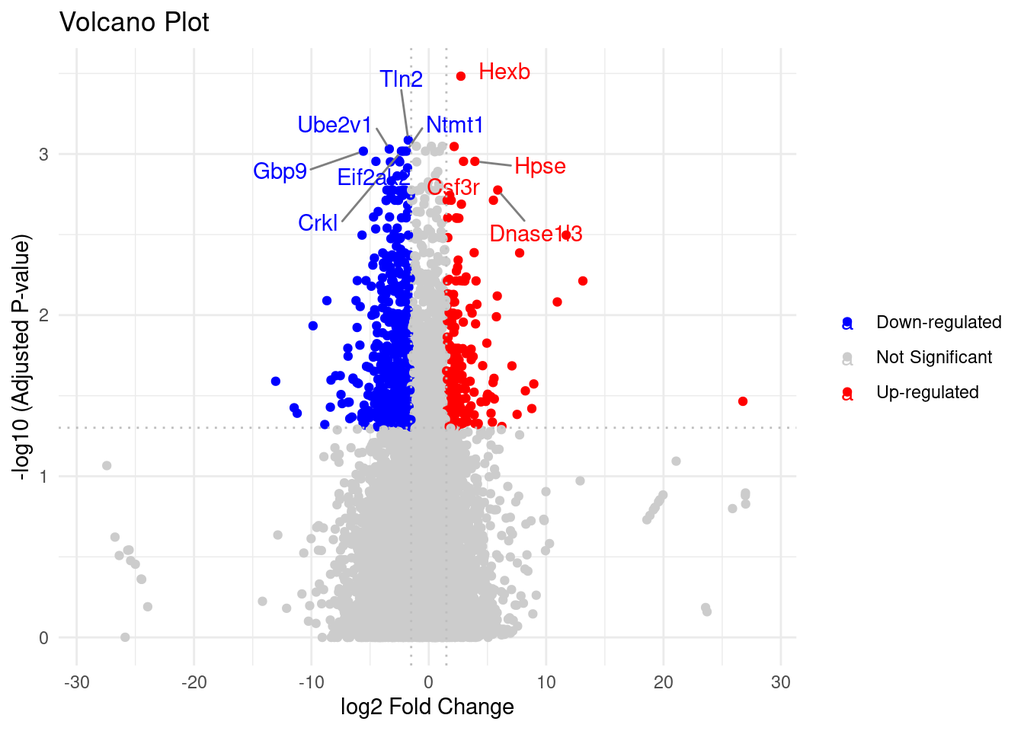

```r
plot_volcano(res_org_df)
```

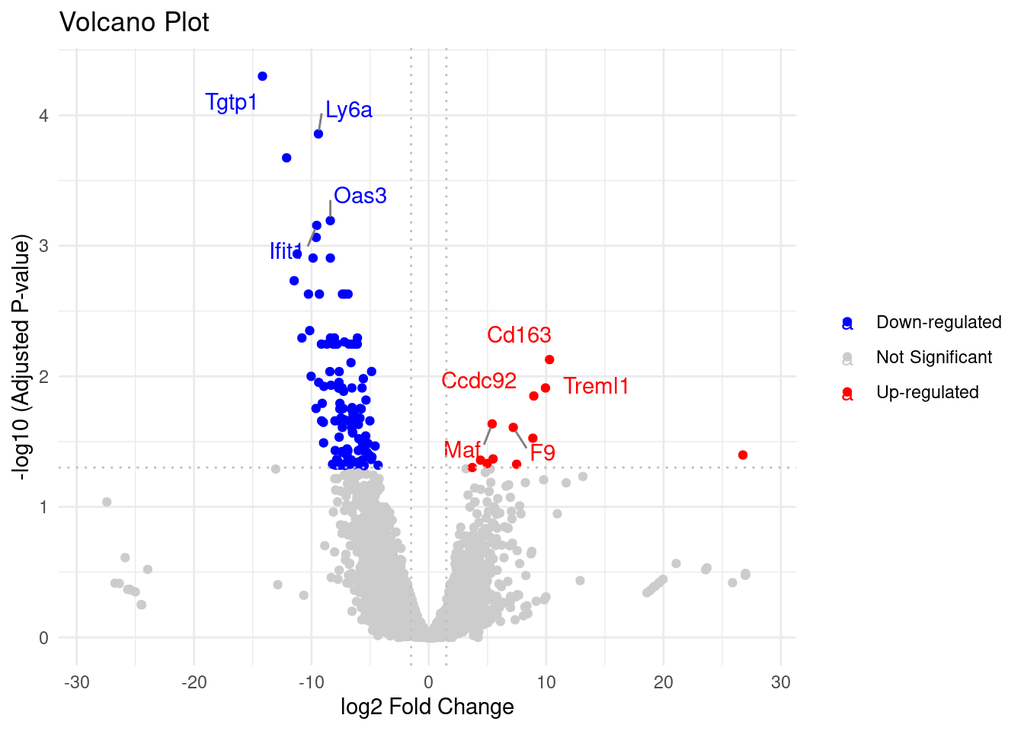

```r
plot_volcano(res_cond_df)
```

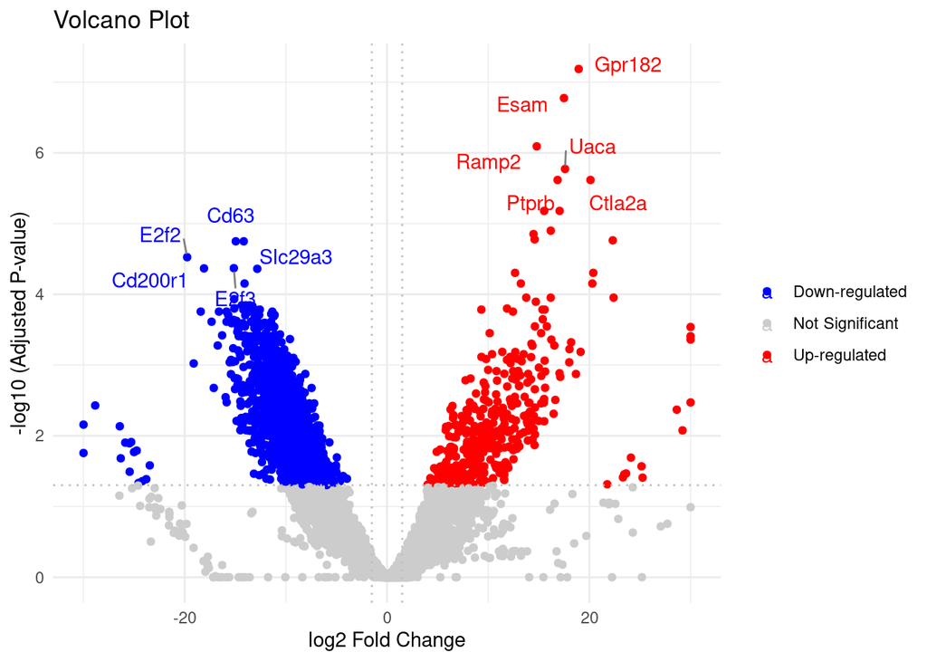

```r
plot_volcano(res_int_df)
```

```r
vsd <- vst(dds_filtered)
```

```
using 'avgTxLength' from assays(dds), correcting for library size
```

```r
# Function to plot top N genes
plot_heatmap <- function(vsd, DESeq2res_df, title){
  top_genes <- DESeq2res_df %>% filter(padj < 0.05) %>%
    arrange(desc(abs(log2FoldChange))) %>%
    head(50)
  mat <- assay(vsd)[top_genes$gene_ensembl_ID, ]
  mat <- mat - rowMeans(mat)
  pheatmap(mat,
           annotation_col = as.data.frame(colData(vsd)[, c("Organ", "condition")]),
           show_rownames = FALSE,
           main = title)
}
```

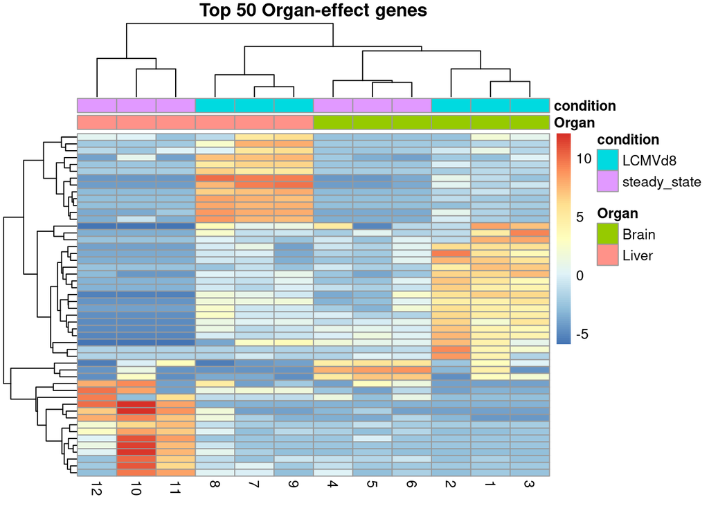

```r
plot_heatmap(vsd, res_org_df,  "Top 50 Organ-effect genes")
```

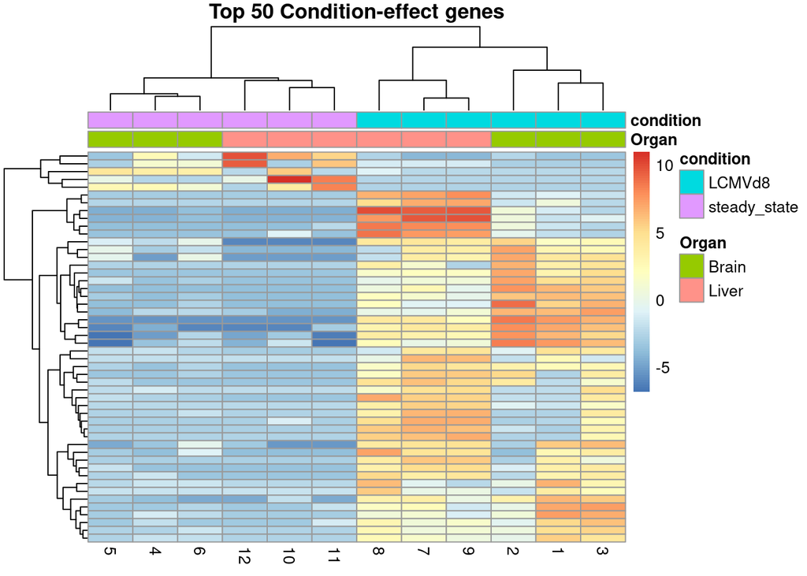

```r
plot_heatmap(vsd, res_cond_df, "Top 50 Condition-effect genes")
```

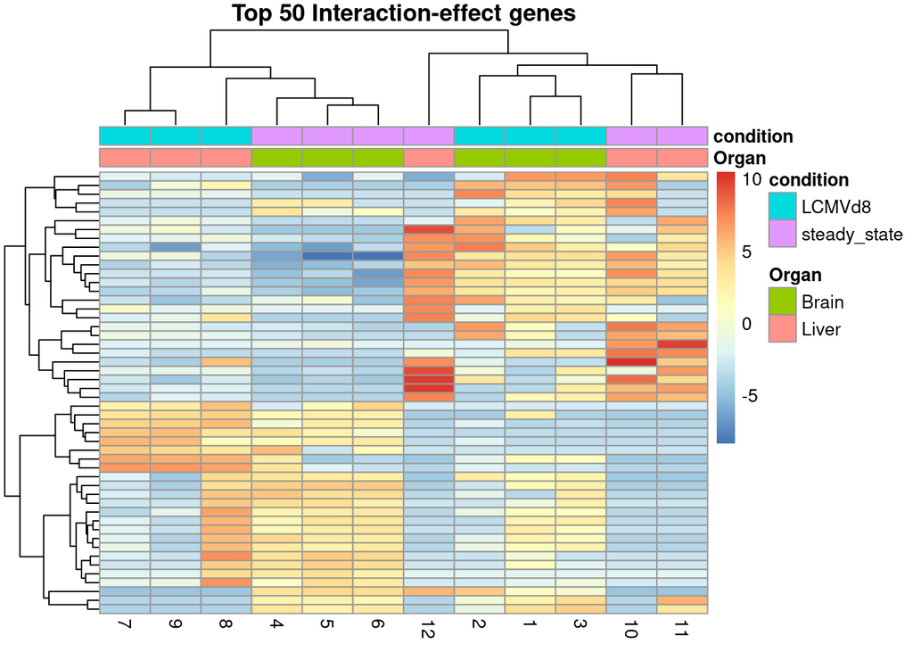

```r
plot_heatmap(vsd, res_int_df,  "Top 50 Interaction-effect genes")
```

This shows how many genes are uniquely driven by organ, condition, or interaction effects, and how much they overlap.

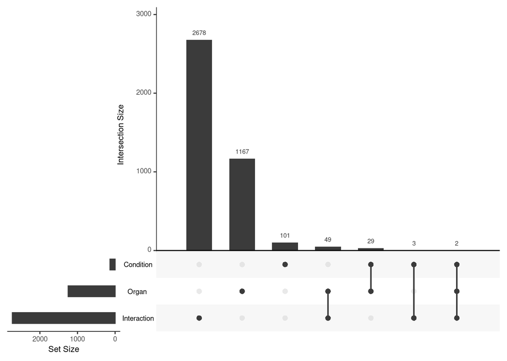

```r
sig_sets <- list(
  Organ = res_org_df %>% filter(padj < 0.05) %>% pull(gene_ensembl_ID),
  Condition = res_cond_df %>% filter(padj < 0.05) %>% pull(gene_ensembl_ID),
  Interaction = res_int_df %>% filter(padj < 0.05) %>% pull(gene_ensembl_ID)
)

fromList(sig_sets) %>% upset()
```

```r
res_DE$gene_ensembl_ID <- meta_genes$ensembl_gene_id[match(res_DE$gene, meta_genes$uniprot_gn_id)]
combined_res <- dplyr::inner_join(res_cond_df, res_DE, by="gene_ensembl_ID")

cor(combined_res$padj.x, combined_res$padj.y,
    method = "spearman",
    use = "complete.obs")
```

```
[1] 0.04784244
```

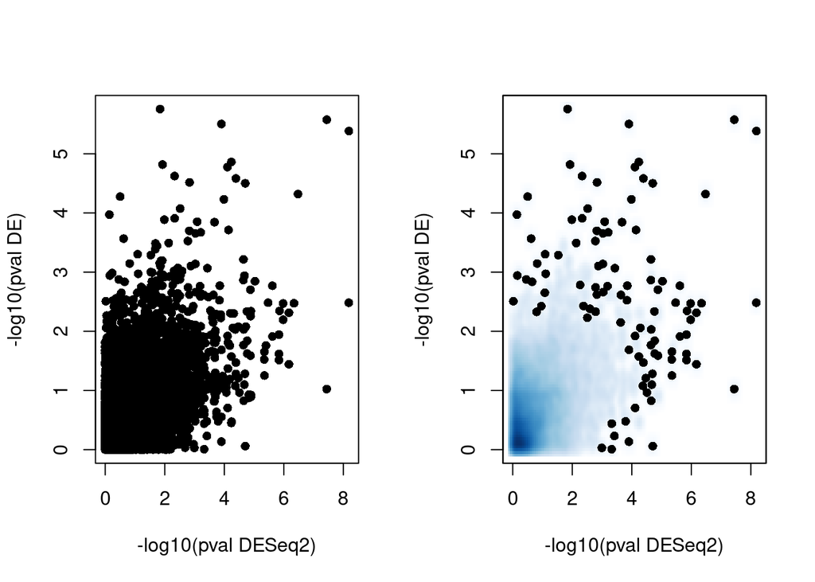

```r
layout(matrix(1:2, nrow=1))
plot(-log10(combined_res$pvalue),
     -log10(combined_res$pval),
     xlab = "-log10(pval DESeq2)", ylab = "-log10(pval DE)", pch=16)
smoothScatter(-log10(combined_res$pvalue),
              -log10(combined_res$pval),
              xlab = "-log10(pval DESeq2)", ylab = "-log10(pval DE)", pch=16)
```

Our analysis showed that the two DE methods produced results with almost zero correlation. This confirms that the statistical model is critical, and the `DESeq2` results, which are based on a model specifically designed for raw counts, are the more statistically appropriate choice.

```r
table(p.adjust(combined_res$pvalue, method="bonferroni") < 0.1,
      p.adjust(combined_res$pval, method="bonferroni") < 0.1)
```

```
        FALSE  TRUE
  FALSE 13503     2
  TRUE     19     2
```

**Striking results(!!)**

## **Grouping of the identified DEGs**

We proceed with the results from DESeq2

```r
# Find both up and down genes
lfc_threshold <- 1.5
padj_threshold <- 0.05

res_int_df$DE <- res_int_df$padj < padj_threshold &
                    abs(res_int_df$log2FoldChange) > lfc_threshold
DEG <- res_int_df$gene_ensembl_ID[which(res_int_df$DE)]

avg_expr <- sapply(sort(unique(meta$group)), function(g) {
  rowMeans(abundances[DEG, which(meta$group == g), drop = FALSE])
})
colnames(avg_expr) <- sort(unique(meta$group))

max_layer_DEG <- setNames(colnames(avg_expr)[apply(abs(avg_expr[DEG,]), 1, which.max)], DEG)
```

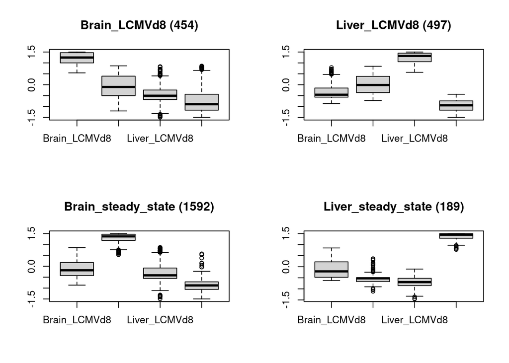

```r
avg_expr_DEG_list <- tapply(names(max_layer_DEG), max_layer_DEG, function(x) avg_expr[x,])
scaled_expr_DEG_list <- lapply(avg_expr_DEG_list, function(x) t(scale(t(x))))

layout(matrix(1:4,nrow=2, ncol=2))
for(group in names(scaled_expr_DEG_list)){
  boxplot(scaled_expr_DEG_list[[group]],
          main = paste0(group, " (", nrow(scaled_expr_DEG_list[[group]]), ")"))}
```

```r
layout(matrix(1, ncol=1))
```

## Clustering

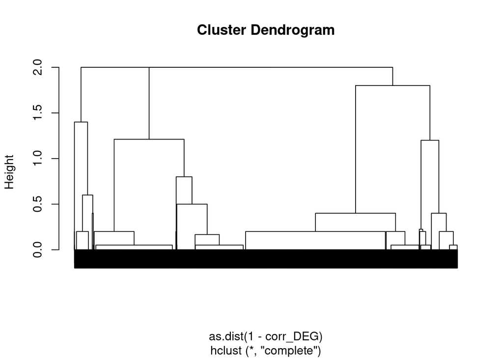

```r
corr_DEG <- cor(t(avg_expr), method = "spearman")
hcl_DEG <- hclust(as.dist(1 - corr_DEG), method = "complete")
plot(hcl_DEG, labels = FALSE)
```

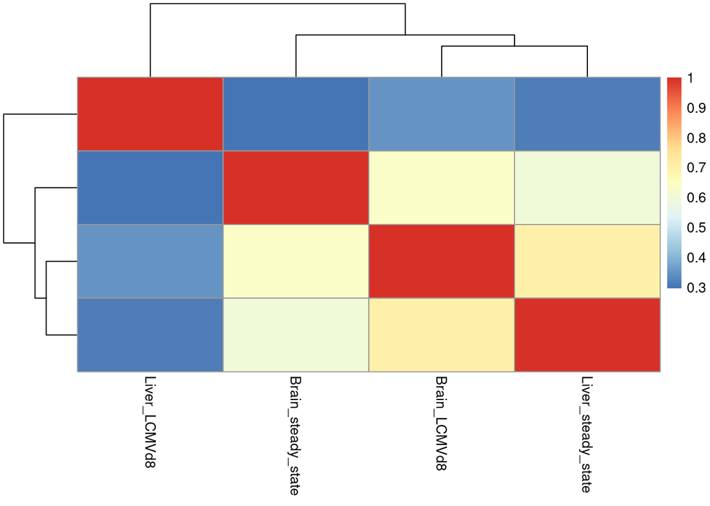

```r
library(pheatmap)
pheatmap(cor(avg_expr),
  show_rownames = FALSE, cluster_rows = hclust(as.dist(1-cor(avg_expr))), cluster_cols = hclust(as.dist(1-cor(avg_expr))))
```

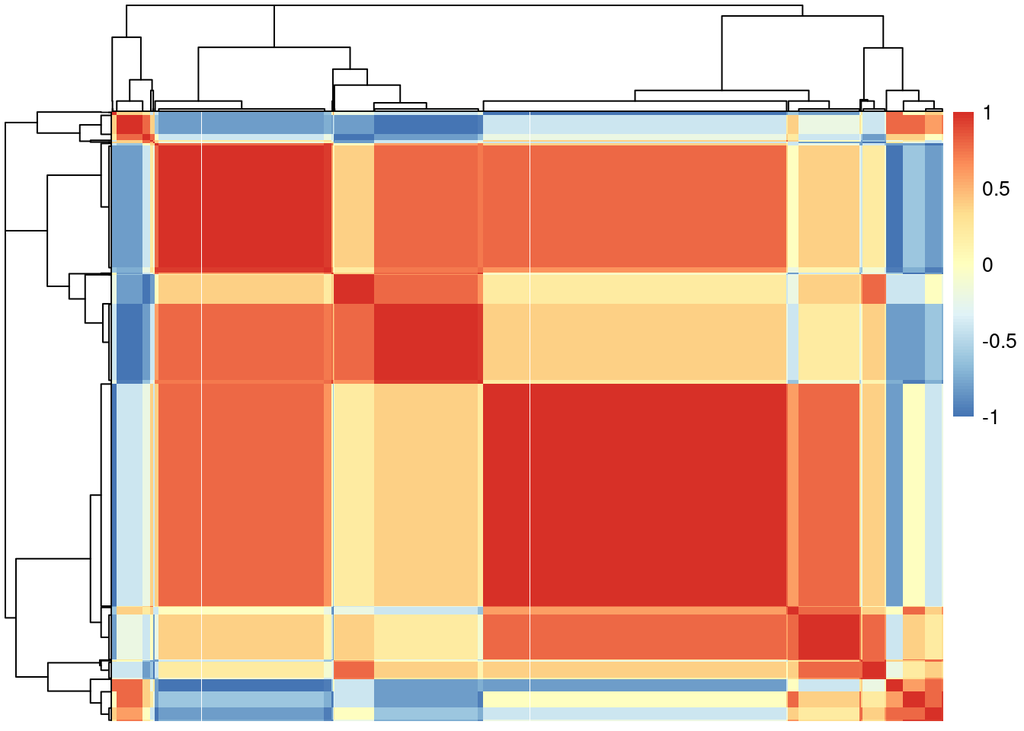

```r
pheatmap(corr_DEG,
  cluster_rows = hcl_DEG,  cluster_cols = hcl_DEG,
  show_rownames = FALSE, show_colnames = FALSE
)
```

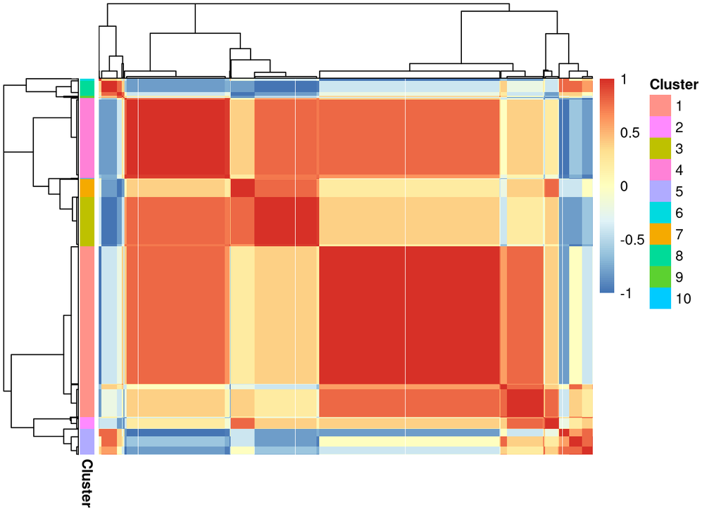

```r
cl_DEG <- cutree(hcl_DEG, k = 10)
annotation_for_rows <- data.frame(
  Cluster = as.factor(cl_DEG)
)
rownames(annotation_for_rows) <- names(cl_DEG)
pheatmap(corr_DEG,
  cluster_rows = hcl_DEG, cluster_cols = hcl_DEG,
  show_rownames = FALSE, show_colnames = FALSE,
  annotation_row = annotation_for_rows
  # annotation_legend = FALSE
)
```

```r
unique(cl_DEG[hcl_DEG$order])
```

```
 [1]  6  8  9  4 10  7  3  1  2  5
```

## **Making sense of the genes**

### **Enrichment analysis: frequency comparison (DAVID)**

```r
# write.table(names(which(cl_DEG==2)),
#             file = "genes_C2.txt",
#             quote = F, row.names = F, col.names = F)
# write.table(names(which(cl_DEG==4)),
#             file = "genes_C4.txt",
#             quote = F, row.names = F, col.names = F)
# write.table(names(which(cl_DEG==5)),
#             file = "genes_C5.txt",
#             quote = F, row.names = F, col.names = F)
# write.table(meta_genes[meta_genes$expressed, "ensembl_gene_id"],
#             file = "genes_expressed.txt",
#             quote = F, row.names = F, col.names = F)
```

```r
# table_c2 <- fread("DAVIDChartReport_genes_C2_2025-11-06.csv")
# head(table_c2)
#
# table_c4 <- fread("DAVIDChartReport_genes_C4_2025-11-05.csv")
# head(table_c4)
#
# table_c5 <- fread("DAVIDChartReport_genes_C5_2025-11-05.csv")
# head(table_c5)
```

### **Enrichment analysis: rank distribution comparison**

```r
# res_DESeq2_df <- res_DESeq2_df %>% arrange(padj, desc(abs(log2FoldChange)))
# write.table(res_DESeq2_df,
#             file = "res_DESeq2.txt", row.names = F)
```

## Mapping Quality

```r
library(tidyverse)
plot_mapping_rate <- function(mapping_stat_file, t) {
  mapping <- read_lines(mapping_stat_file) %>%
  as_tibble()

mapping <- mapping %>%
  separate(value, into = c("Filename", "Content"), sep = ":", extra = "merge") %>%
  separate(Content, into = c("Metric", "Value"), sep = "\\|") %>%
    mutate(across(everything(), trimws))
  mapping$Sample <- str_extract(mapping$Filename, "SRR\\d+")
  mapping$Type <- ifelse(str_detect(mapping$Metric, "%"), "Percentage", "Count")
  mapping$Metric <- str_remove(mapping$Metric, "(Number|%) of reads unmapped: ")

  mapping %>%
    filter(Type == "Percentage") %>%
    ggplot(aes(x = Sample, y = as.numeric(str_remove(Value, "%")), fill = Metric)) +
    geom_col(position = "dodge") +
    labs(
      title = paste("Unmapped Reads: ", t),
      y = "Percentage of Total Reads",
      x = "Sample",
      fill = "Reason"
    ) + ylim(0,72) +
    theme(axis.text.x = element_text(angle = 45, hjust = 1))
}
```

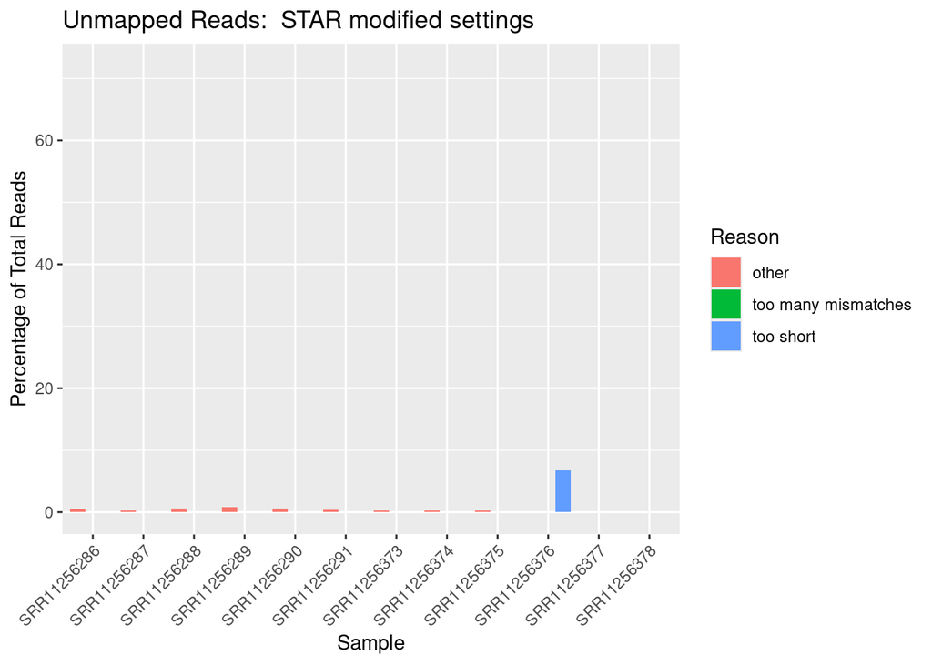

```r
plot_mapping_rate("./mapping_stat_modified_threshold.txt", "STAR modified settings")
```

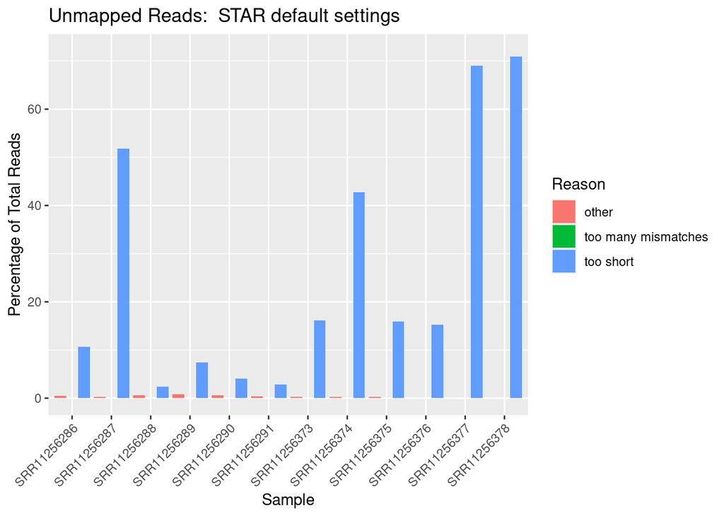

```r
plot_mapping_rate("./mapping_stat.txt", "STAR default settings")
```